# Reproducible Research: Peer Assessment 1

## Loading and preprocessing the data

Let’s start by downloading, unzipping and loading the data from the repository.

```r
if (!file.exists("activity.csv")) {
    download.file(
        "http://d396qusza40orc.cloudfront.net/repdata%2Fdata%2Factivity.zip",
                  "activity.zip")
    unzip("activity.zip")
}

activity <- read.csv(file = "activity.csv")
```

Check out how the data looks like.

```r
head(activity)
```

```
##   steps       date interval
## 1    NA 2012-10-01        0
## 2    NA 2012-10-01        5
## 3    NA 2012-10-01       10
## 4    NA 2012-10-01       15
## 5    NA 2012-10-01       20
## 6    NA 2012-10-01       25
```

```r
str(activity)
```

```
## 'data.frame':    17568 obs. of  3 variables:
##  $ steps   : int  NA NA NA NA NA NA NA NA NA NA ...
##  $ date    : Factor w/ 61 levels "2012-10-01","2012-10-02",..: 1 1 1 1 1 1 1 1 1 1 ...
##  $ interval: int  0 5 10 15 20 25 30 35 40 45 ...
```

Copy activity with NA values to **activity.na**:

```r
activity.na <- activity
```

Let’s filter out the NA values.

```r
activity <- subset(activity, !is.na(steps))
```

Check out how the filtered data looks like.

```r
head(activity)
```

```
##     steps       date interval
## 289     0 2012-10-02        0
## 290     0 2012-10-02        5
## 291     0 2012-10-02       10
## 292     0 2012-10-02       15
## 293     0 2012-10-02       20
## 294     0 2012-10-02       25
```

```r
str(activity)
```

```
## 'data.frame':    15264 obs. of  3 variables:
##  $ steps   : int  0 0 0 0 0 0 0 0 0 0 ...
##  $ date    : Factor w/ 61 levels "2012-10-01","2012-10-02",..: 2 2 2 2 2 2 2 2 2 2 ...
##  $ interval: int  0 5 10 15 20 25 30 35 40 45 ...
```

## What is mean total number of steps taken per day?

Total number of steps for each days:

```r
steps.per.day <- tapply(activity$steps, activity$date, sum)
steps.per.day[is.na(steps.per.day)] <- 0
steps.per.day
```

```
## 2012-10-01 2012-10-02 2012-10-03 2012-10-04 2012-10-05 2012-10-06
##          0        126      11352      12116      13294      15420
## 2012-10-07 2012-10-08 2012-10-09 2012-10-10 2012-10-11 2012-10-12
##      11015          0      12811       9900      10304      17382
## 2012-10-13 2012-10-14 2012-10-15 2012-10-16 2012-10-17 2012-10-18
##      12426      15098      10139      15084      13452      10056
## 2012-10-19 2012-10-20 2012-10-21 2012-10-22 2012-10-23 2012-10-24
##      11829      10395       8821      13460       8918       8355
## 2012-10-25 2012-10-26 2012-10-27 2012-10-28 2012-10-29 2012-10-30
##       2492       6778      10119      11458       5018       9819
## 2012-10-31 2012-11-01 2012-11-02 2012-11-03 2012-11-04 2012-11-05
##      15414          0      10600      10571          0      10439
## 2012-11-06 2012-11-07 2012-11-08 2012-11-09 2012-11-10 2012-11-11
##       8334      12883       3219          0          0      12608
## 2012-11-12 2012-11-13 2012-11-14 2012-11-15 2012-11-16 2012-11-17
##      10765       7336          0         41       5441      14339
## 2012-11-18 2012-11-19 2012-11-20 2012-11-21 2012-11-22 2012-11-23
##      15110       8841       4472      12787      20427      21194
## 2012-11-24 2012-11-25 2012-11-26 2012-11-27 2012-11-28 2012-11-29
##      14478      11834      11162      13646      10183       7047
## 2012-11-30
##          0
```

Now visualize it with a histogram:

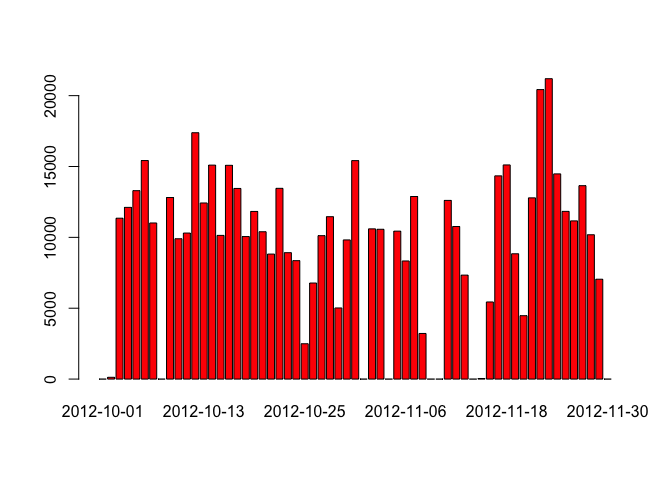

```r
barplot(steps.per.day, col = "red")
```

The mean and the median of the total steps per day (different than *mean/median of steps per day*)

```r
mean(steps.per.day)
```

```
## [1] 9354.23
```

```r
median(steps.per.day)
```

```
## [1] 10395
```

> **NOTE:** Results may vary because total steps with NA per day are taken as 0 for continuous time series.

## What is the average daily activity pattern?

First of all take means of steps for each interval across all days.

```r
steps.per.interval <- tapply(activity$steps, activity$interval, mean)
steps.per.interval
```

```
##           0           5          10          15          20          25
##   1.7169811   0.3396226   0.1320755   0.1509434   0.0754717   2.0943396
##          30          35          40          45          50          55
##   0.5283019   0.8679245   0.0000000   1.4716981   0.3018868   0.1320755
##         100         105         110         115         120         125
##   0.3207547   0.6792453   0.1509434   0.3396226   0.0000000   1.1132075
##         130         135         140         145         150         155
##   1.8301887   0.1698113   0.1698113   0.3773585   0.2641509   0.0000000
##         200         205         210         215         220         225
##   0.0000000   0.0000000   1.1320755   0.0000000   0.0000000   0.1320755
##         230         235         240         245         250         255
##   0.0000000   0.2264151   0.0000000   0.0000000   1.5471698   0.9433962
##         300         305         310         315         320         325
##   0.0000000   0.0000000   0.0000000   0.0000000   0.2075472   0.6226415
##         330         335         340         345         350         355
##   1.6226415   0.5849057   0.4905660   0.0754717   0.0000000   0.0000000
##         400         405         410         415         420         425
##   1.1886792   0.9433962   2.5660377   0.0000000   0.3396226   0.3584906
##         430         435         440         445         450         455
##   4.1132075   0.6603774   3.4905660   0.8301887   3.1132075   1.1132075
##         500         505         510         515         520         525
##   0.0000000   1.5660377   3.0000000   2.2452830   3.3207547   2.9622642
##         530         535         540         545         550         555
##   2.0943396   6.0566038  16.0188679  18.3396226  39.4528302  44.4905660
##         600         605         610         615         620         625
##  31.4905660  49.2641509  53.7735849  63.4528302  49.9622642  47.0754717
##         630         635         640         645         650         655
##  52.1509434  39.3396226  44.0188679  44.1698113  37.3584906  49.0377358
##         700         705         710         715         720         725
##  43.8113208  44.3773585  50.5094340  54.5094340  49.9245283  50.9811321
##         730         735         740         745         750         755
##  55.6792453  44.3207547  52.2641509  69.5471698  57.8490566  56.1509434
##         800         805         810         815         820         825
##  73.3773585  68.2075472 129.4339623 157.5283019 171.1509434 155.3962264
##         830         835         840         845         850         855
## 177.3018868 206.1698113 195.9245283 179.5660377 183.3962264 167.0188679
##         900         905         910         915         920         925
## 143.4528302 124.0377358 109.1132075 108.1132075 103.7169811  95.9622642
##         930         935         940         945         950         955
##  66.2075472  45.2264151  24.7924528  38.7547170  34.9811321  21.0566038
```

[output cut: 41 more lines]

```
##  19.6226415  19.0188679  19.3396226  33.3396226  26.8113208  21.1698113
##        2030        2035        2040        2045        2050        2055
##  27.3018868  21.3396226  19.5471698  21.3207547  32.3018868  20.1509434
##        2100        2105        2110        2115        2120        2125
##  15.9433962  17.2264151  23.4528302  19.2452830  12.4528302   8.0188679
##        2130        2135        2140        2145        2150        2155
##  14.6603774  16.3018868   8.6792453   7.7924528   8.1320755   2.6226415
##        2200        2205        2210        2215        2220        2225
##   1.4528302   3.6792453   4.8113208   8.5094340   7.0754717   8.6981132
##        2230        2235        2240        2245        2250        2255
##   9.7547170   2.2075472   0.3207547   0.1132075   1.6037736   4.6037736
##        2300        2305        2310        2315        2320        2325
##   3.3018868   2.8490566   0.0000000   0.8301887   0.9622642   1.5849057
##        2330        2335        2340        2345        2350        2355
##   2.6037736   4.6981132   3.3018868   0.6415094   0.2264151   1.0754717
```

After that get levels of intervals as an array called **Interval**.

```r
Interval <- as.numeric(levels(as.factor(activity$interval)))
Interval
```

```
##   [1]    0    5   10   15   20   25   30   35   40   45   50   55  100  105
##  [15]  110  115  120  125  130  135  140  145  150  155  200  205  210  215
##  [29]  220  225  230  235  240  245  250  255  300  305  310  315  320  325
##  [43]  330  335  340  345  350  355  400  405  410  415  420  425  430  435
##  [57]  440  445  450  455  500  505  510  515  520  525  530  535  540  545
##  [71]  550  555  600  605  610  615  620  625  630  635  640  645  650  655
##  [85]  700  705  710  715  720  725  730  735  740  745  750  755  800  805
##  [99]  810  815  820  825  830  835  840  845  850  855  900  905  910  915
## [113]  920  925  930  935  940  945  950  955 1000 1005 1010 1015 1020 1025
## [127] 1030 1035 1040 1045 1050 1055 1100 1105 1110 1115 1120 1125 1130 1135
## [141] 1140 1145 1150 1155 1200 1205 1210 1215 1220 1225 1230 1235 1240 1245
## [155] 1250 1255 1300 1305 1310 1315 1320 1325 1330 1335 1340 1345 1350 1355
## [169] 1400 1405 1410 1415 1420 1425 1430 1435 1440 1445 1450 1455 1500 1505
## [183] 1510 1515 1520 1525 1530 1535 1540 1545 1550 1555 1600 1605 1610 1615
## [197] 1620 1625 1630 1635 1640 1645 1650 1655 1700 1705 1710 1715 1720 1725
## [211] 1730 1735 1740 1745 1750 1755 1800 1805 1810 1815 1820 1825 1830 1835
## [225] 1840 1845 1850 1855 1900 1905 1910 1915 1920 1925 1930 1935 1940 1945
## [239] 1950 1955 2000 2005 2010 2015 2020 2025 2030 2035 2040 2045 2050 2055
## [253] 2100 2105 2110 2115 2120 2125 2130 2135 2140 2145 2150 2155 2200 2205
## [267] 2210 2215 2220 2225 2230 2235 2240 2245 2250 2255 2300 2305 2310 2315
## [281] 2320 2325 2330 2335 2340 2345 2350 2355
```

Finally plot the time series using **base** plot system.

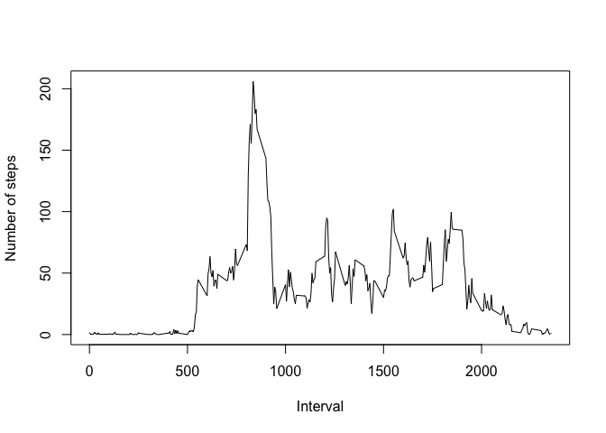

```r
plot(Interval, steps.per.interval, type = "l", ylab = "Number of steps")
```

Now it’s easy to retrieve the interval with the maximum steps:

```r
max.steps <- max(steps.per.interval)
max.interval <- steps.per.interval[steps.per.interval == max.steps]
as.numeric(names(max.interval))
```

```
## [1] 835
```

The interval with the maximum steps is **835** (i.e. 8:35-8:40)

## Imputing missing values

Let’s start by counting rows with *NA* values:

```r
sum(is.na(activity.na$steps))
```

```
## [1] 2304
```

```r
activity.imputed <- activity.na
activity.imputed$steps[1] <- steps.per.interval[1]
length.activity <- nrow(activity.imputed)
for (i in 2:length.activity - 1) {
    if (is.na(activity.imputed$steps[i])) {
        prev <- activity.imputed$steps[i - 1]; nxt <- activity.imputed$steps[i + 1]
        activity.imputed$steps[i] <- if (!is.na(prev) && !is.na(nxt)) {
            (prev + nxt) / 2
        } else {
            steps.per.interval[as.numeric(names(steps.per.interval)) ==
                                   activity.imputed$interval[i]]
        }
    }
}
activity.imputed$steps[length.activity] <- steps.per.interval[
    as.numeric(names(steps.per.interval)) == activity.imputed$interval[length.activity]]
```

Now check out the new data:

```r
head(activity.imputed)
```

```
##       steps       date interval
## 1 1.7169811 2012-10-01        0
## 2 0.3396226 2012-10-01        5
## 3 0.1320755 2012-10-01       10
## 4 0.1509434 2012-10-01       15
## 5 0.0754717 2012-10-01       20
## 6 2.0943396 2012-10-01       25
```

```r
tail(activity.imputed)
```

```
##           steps       date interval
## 17563 2.6037736 2012-11-30     2330
## 17564 4.6981132 2012-11-30     2335
## 17565 3.3018868 2012-11-30     2340
## 17566 0.6415094 2012-11-30     2345
## 17567 0.2264151 2012-11-30     2350
## 17568 1.0754717 2012-11-30     2355
```

```r
str(activity.imputed)
```

```
## 'data.frame':    17568 obs. of  3 variables:
##  $ steps   : num  1.717 0.3396 0.1321 0.1509 0.0755 ...
##  $ date    : Factor w/ 61 levels "2012-10-01","2012-10-02",..: 1 1 1 1 1 1 1 1 1 1 ...
##  $ interval: int  0 5 10 15 20 25 30 35 40 45 ...
```

Check out how does it look like in comparison with the original dataset:

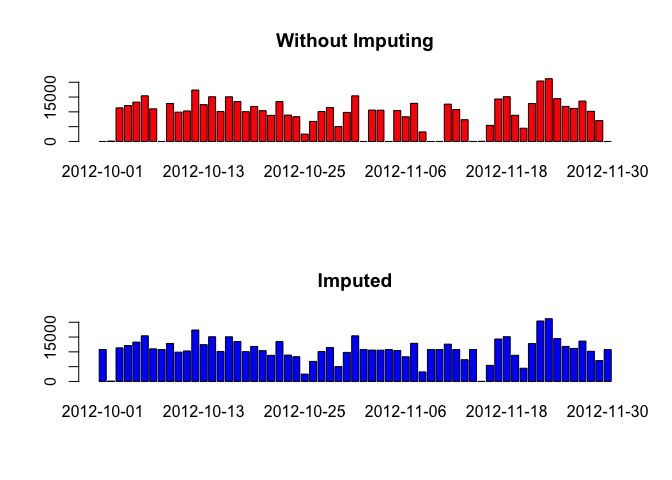

```r
steps.per.day.imputed <- tapply(activity.imputed$steps, activity.imputed$date, sum)
steps.per.day.imputed[is.na(steps.per.day)] <- 0
par(mfrow = c(2, 1))
barplot(steps.per.day, col = "red", main = "Without Imputing")
barplot(steps.per.day.imputed, col = "blue", main = "Imputed")
```

Now calculate the new mean and median and compare it to the original:

```r
library(xtable)
dt.original <- data.frame(mean = mean(steps.per.day),
                          median = median(steps.per.day))
dt.imputed <- data.frame(mean = mean(steps.per.day.imputed),
                         median = median(steps.per.day.imputed))
dt.table <- rbind(dt.original, dt.imputed)
row.names(dt.table) <- c("original", "imputed")
xt <- xtable(dt.table)
print(xt, type = "html")
```

|  | mean | median |
| --- | --- | --- |
| original | 9354.23 | 10395.00 |
| imputed | 10766.09 | 10765.23 |

This table clearly shows that imputing increased both median and mean and also made mean and median closer to each other because of eliminating sudden jumps in data.

## Are there differences in activity patterns between weekdays and weekends?

First create the factor variable:

```r
activity.imputed <- transform(activity.imputed,
                              date = strptime(date, "%Y-%m-%d"))
activity.imputed <- transform(activity.imputed,
                              weekday = weekdays(date))
activity.imputed$weekday <- as.factor(sapply(activity.imputed$weekday, function(wd) {
    if (wd == "Saturday" | wd == "Sunday") "weekend" else "weekday"
}))
table(activity.imputed$weekday)
```

```
##
## weekday weekend
##   12960    4608
```

Now summarize data over interval and weekday type:

```r
steps.per.interval.weekday <- with(activity.imputed, aggregate(steps,
                                        list(weekday, interval), mean))
colnames(steps.per.interval.weekday) <- c("weekday", "interval", "steps")
head(steps.per.interval.weekday)
```

```
##   weekday interval      steps
## 1 weekday        0 2.25115304
## 2 weekend        0 0.21462264
## 3 weekday        5 0.44528302
## 4 weekend        5 0.04245283
## 5 weekday       10 0.17316562
## 6 weekend       10 0.01650943
```

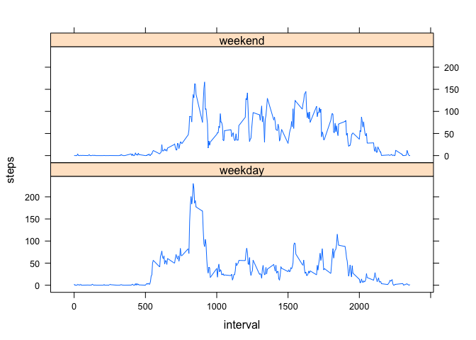

```r
library(lattice)
xyplot(steps ~ interval | weekday, data = steps.per.interval.weekday,
       layout = c(1, 2), type = 'l')
```